# Chapter 2. First-Order Differential Equations

## Contents

- Solution Curves Without a Solution
- Separable Equations
- Linear Equations
- Exact Equations
- Solutions by Substitutions
- A Numerical Method
- Linear Models
- Nonlinear Models
- Modeling with Systems of First-Order DEs

## 2.1 Solution Curves Without a Solution

- DEs can be analyzed qualitatively, allowing us to approximate a solution curve without solving the problem
- Two approches are:
  - Direction fields
  - Autonomous first-order DEs
- Direction fields:
  - $\displaystyle\frac{dy}{dx}=\sin y$

[figure not shown]

  - Slope of the **lineal element** at $(x,y(x))$ on a solution curve is the value of $\displaystyle\frac{dy}{dx}$ at this point
  - **Direction/slope fields** of $\displaystyle\frac{dy}{dx}=f(x,y)$ are collections of lineal slope elements that visually suggest the shape of a family of solution curves
- **Autonomous** first-order DEs, $\displaystyle\frac{dy}{dx}=f(y)$
  - An ODE in which the independent variable does not appear explicitly

    $\begin{align*} \frac{dy}{dx} &= 1+y^2 & \mathrm{autonomous} \\ \frac{dy}{dx} &= 0.2xy & \mathrm{nonautonomous} \end{align*}$
  - **Critical points**, $f(c)=0$, are constant (or equilibrium) solutions of autonomous DEs
  - A **phase portrait** is made by putting critical points on a virtical line with phase lines pointing up or down, depending on the sign of the function over intervals between the points
  - Some conclusions can be drawn about nonconstant solution curves to autonomous DEs
    - If a solution $y(x)$ passes through $(x_0,y_0)$ in subregion $R_i$ then $y(x)$ remains in $R_i$
    - By continuity of $f$, $f(y)$ cannot change signs in a subregion $R_i$
    - Since $f(y)$ is either positive or negative in $R_i$, a solution is either increasing or decreasing and has no relative extremum
  - **Example:** Phase portrait and solution curves

    $\displaystyle\frac{dP}{dt}=P(a-bP)$

[figure not shown]

### Exercises 2.1

1. $\displaystyle\frac{dy}{dx}=x^2-y^2$

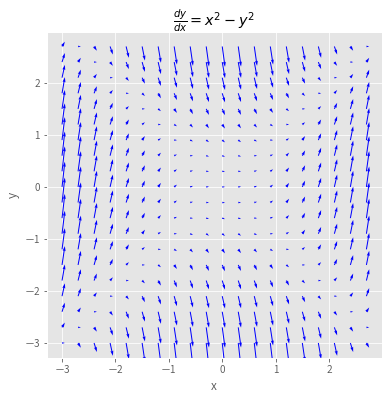

```python
%matplotlib inline
import numpy as np
import matplotlib.pyplot as plt
plt.style.use('ggplot')

nx, ny = .3, .3
x = np.arange(-3, 3, nx)
y = np.arange(-3, 3, ny)

X, Y = np.meshgrid(x, y)

dy = X*X -Y*Y
dx = np.ones(dy.shape)

plt.figure(figsize=(6, 6))
plt.quiver(X, Y, dx, dy, color='Blue')
plt.xlabel('x')
plt.ylabel('y')
plt.title(r'$\frac{dy}{dx}=x^2-y^2$')
plt.show()
```

- 5, 9

## 2.2 Separable Equations

- Consider $\displaystyle\frac{dy}{dx}=f(x,y)$
  - When $f$ does not depend on $y$, $\displaystyle\frac{dy}{dx}=g(x)$, which can be solved by integration
  - The solution $y=\int g(x) dx = G(x)+c$ where $G(x)$ is an antiderivative (indefinite integral)
  - Some functions, termed **nonelementary**, do not possess an antiderivative that is an elementary function
- A first-order DE of the form $\displaystyle\frac{dy}{dx}=g(x)h(y)$ is said to be **separable**, or have **separable variables**
- A separable equation can be rewritten in the form $\displaystyle\frac{1}{h(y)}dy=g(x)dx$, which is solved by integrating both sides
- **Example:** Solving an separable equation $\displaystyle\frac{dy}{dx}=y^2-9$, $y(0)=0$

  Separating and using partial fractions

  $ \begin{align*} \frac{dy}{(y-3)(y+3)} &= dx \\ \frac{1}{6} \left [ \frac{1}{y-3} -\frac{1}{y+3} \right ] dy &= dx \end{align*} $

  Integrating and solving for $u$ yields

  $ \begin{align*} \frac{1}{6} \ln \left | \frac{y-3}{y+3} \right | &= x+c_1\\ &\Downarrow c=e^{6c_1} \\ y &= 3 \frac{1+ce^{6x}}{1-ce^{6x}}& \end{align*} $

  Finally, applying $y(0)=0$ gives $c=-1$

### Exercises 2.2

- 1, 3, 21
- 23, 25
- 31, 36

## 2.3 Linear Equations

A first-order DE of the form $\displaystyle a_1(x) \frac{dy}{dx} +a_0(x)y = g(x)$ is a **linear equation** in the dependent variable $y$

- The DE is **homogeneous** when $g(x)=0$; otherwise, it is **nonhomogeneous**
- The standard form of a linear DE is obtained by dividing both sides by the lead coefficient

  $\displaystyle\frac{dy}{dx}+P(x)y=f(x)$

The **standard form** equation has the property that its solution $y$ is the sum of the solution of the associated homogeneous equation $y_h$ and the particular solution of the nonhomogeneous equation $y_p$: $y=y_h +y_p$

- The homogeneous equation $\displaystyle\frac{dy_h}{dx} +P(x)y_h= 0 $ is separable, allowing us to solve for $y_h$

  $ \begin{align*} \frac{dy_h}{y_h} &= -P(x)dx \\ \ln |y_h| &= -\int P(x)dx +c'\\ y_h &= c \exp\left( -\int P(x) dx \right) \end{align*} $
- **Variation of parameters** $y_p=u(x)y_h$ can be used to solve the nonhomogeneous equation of $y_p$

  $ \begin{align*} y_h \frac{du}{dx} +& \underbrace{\left (\frac{dy_h}{dx} +P(x) y_h \right )}_{=\,0} u = f(x)\\ & du = \frac{f(x)}{y_h} dx \\ & u = \displaystyle\int \frac{f(x)}{y_h(x)} dx \end{align*} $

### Exercises 2.3

- 2, 6, 10, 14
- 26, 28
- 39, 40, 43, 44

## 2.4 Exact Equations

A differential expression $M(x,y)dx + N(x,y)dy$ is an **exact differential** in a region $R$ of the $xy$-plane if it corresponds to the differential of some function $f(x,y)$:

> $\displaystyle df(x,y)=\frac{\partial f}{\partial x} dx + \frac{\partial f}{\partial y} dy$

and a condition of exact differentials is:

> $\displaystyle\frac{\partial M}{\partial y}=\frac{\partial N}{\partial x}$

$M(x,y)dx + N(x,y)dy=0$ is an **exact equation** if the left side is an exact differential

**Example:** Solving an Exact DE, $2xydx+(x^2-1)dy=0$

- With $M(x,y)=2xy$ and $N(x,y)=x^2-1$, we have:

  $\displaystyle\frac{\partial M}{\partial y}=2x=\frac{\partial N}{\partial x}$
- The equation is exact so there exists $f(x,y)$ such that

  $ \begin{align*} \frac{\partial f}{\partial x} &= 2xy \\ \frac{\partial f}{\partial y} &= x^2 -1 \end{align*} $
- Integrating $\displaystyle\frac{\partial f}{\partial x}$ gives

  $f(x,y)=x^2y+g(y)$
- Taking the partial derivative of $\displaystyle\frac{\partial f}{\partial y}$ with respect to $y$ and setting the result equal to $N(x,y)$ gives

  $\displaystyle\frac{\partial f}{\partial y}=x^2+g'(y)=x^2-1$
- It follows that

  $g'(y)=-1$ and $g(y)=-y+c$
- Hence $f(x,y)=x^2y-y+c$ and the solution of the equation in implicit form is

  $x^2y-y+c=0$

**Integrating Factor** of the first-order linear DE

> $ \begin{align*} \frac{dy}{dx} +P(x)y &= f(x)\\ \left ( P(x)y -f(x) \right )dx +dy &= 0\\ &\Downarrow \times \; I(x): \mathbf{Integrating} \; \mathbf{Factor}\\ I(x)\left ( P(x)y -f(x) \right )dx +I(x)dy &= 0 \\ \\ \mathbf{To\; be\; an\; exact \;equation\;}&\big\Downarrow \\ \frac{\partial}{\partial y} \left\{I(x)\left( P(x)y -f(x) \right) \right \} &= I(x) P(x) =\frac{\partial}{\partial x} I(x) \\ I(x) &= \exp\left(\int P(x) dx\right) \end{align*}$

> Then

> $\begin{align*} I(x) \frac{dy}{dx} +I(x) P(x)y &= I(x)f(x)\\ \frac{d}{dx}\left\{ I(x)y \right \} &= I(x)f(x)\\ &\Downarrow \\ y = c I(x)^{-1} &+I(x)^{-1} \int I(x) f(x) dx \end{align*}$

**Example:** Solve $\displaystyle\frac{dy}{dx} -2xy = 2, \;y(0)=1$

*Solution*

$ \begin{align*} \frac{dy}{dx} -2xy &= 2\\ & \Downarrow \times \;e^{-x^2} \\ \frac{d}{dx}[e^{-x^2}y] &= 2e^{-x^2}\\ y &= c e^{x^2} +2e^{x^2} \int_0^x e^{-t^2} dt\\ & \big\Downarrow \;y(0) = 1 \rightarrow c=1 \\ y &= e^{x^2} \left[ 1 +\sqrt{\pi} \underbrace{\left(\frac{2}{\sqrt{\pi}} \int_0^x e^{-t^2} dt \right)}_{\mathrm{erf} (x)} \right ] \end{align*} $

### Exercises 2.4

- 1, 3, 5, 7
- 21, 23, 27
- 32, 34

## 2.5 Solutions by Substitutions

**Substitution** is often used to get a DE in a form such that a known procedure can be used to find a solution

- Reduction to separation of variables can be facilitated in the DE $\displaystyle\frac{dy}{dx}=f(Ax+By+C)$ by substituting

  $u=Ax+By+C, \;B \neq 0$

  **Example:** Solve the IVP $\displaystyle\frac{dy}{dx} = (-2x +y)^2 -7, \;y(0)=0$

  Let $u=-2x+y$, then $\displaystyle\frac{du}{dx}=-2 + \frac{dy}{dx}$ giving

  $\displaystyle\frac{du}{dx} = u^2 -9$
- **Homogeneous** first-order DE

  A first-order ordinary DE in the form:

  > $\displaystyle\frac{dy}{dx}=f(x,y) = - \frac{M(x,y)}{N(x,y)}$

  is a homogeneous type if both function $M(x,y)$ and $N(x,y)$ are homogeneous functions of the same degree $n$:

  > $M(\lambda x, \lambda y) = \lambda^n M(x, y), \;\; N(\lambda x, \lambda y) = \lambda^n N(x, y)$.

  Thus, we can let $t=\frac{1}{x}$ to simplify this quotient to a function $f$ of the single variable $\frac{y}{x}$:

  > $\displaystyle\frac{M(x, y)}{N(x, y)}=\frac{M(t x,t y)}{N(t x, t y)} = \frac{M\left(1, \frac{y}{x}\right)}{N\left(1,\frac{y}{x}\right)}=-f\left(\frac{y}{x}\right)$.

  That is,

  > $\displaystyle\frac{dy}{dx}=f\left(\frac{y}{x}\right)$

  The change of variables $y=ux$ transforms the original differential equation into the separable form;

  > $\displaystyle\frac{du}{f(u)-u}=\frac{dx}{x}$
- **Bernoulli** DE: $y'+P(x)y =Q(x)y^{n}$ where $n \neq 0$ and $n \neq 1$

  Bernoulli equations are special because they are nonlinear differential equations with known exact solutions. The substitution $u=y^{1-n}$ reduces any Bernoulli equation to a linear differential equation.

  **Example:** Solve $\displaystyle y'-\frac{2}{x}y=-x^2y^2$

  Changing variables $\displaystyle u=\frac{1}{y}$, $\displaystyle u'=-\frac{1}{y^2}y'$ gives the equation

  > $\displaystyle u'+\frac{2}{x}u=x^2$
- **Riccatti** DE

  Riccati equation is any first-order ordinary differential equation that is quadratic in the unknown function. In other words, it is an equation of the form

  > $y'=q_0(x)+q_1(x)y+q_2(x)y^2$, where $q_0(x)\neq 0$ and $q_2(x)\neq 0$.

  The new variable $v=yq_2$ satisfies a Riccati equation of the form

  > $v'=v^2+R(x)v+S(x)$

  where $S=q_2 q_0$ and $\displaystyle R=q_{1}+\left({\frac{q_{2}'}{q_{2}}}\right)$. Substituting $\displaystyle v=-\frac{u'}{u\,}$, it follows that $u$ satisfies the linear 2nd order ODE

  > $u''-R(x)u'+S(x)u=0$.

  A solution of this equation will lead to a solution $\displaystyle y=-\frac{u'}{q_2u}$ of the original Riccati equation.

### Exercises 2.5

- 1, 4, 7, 10
- 11, 12
- 15, 20, 29
- 35, 37

## 2.6 A Numerical Method

**Numerical method:** an algorithm for approximating the unknown solution to a DE

- **Linearization** approximates solutions within a small area around lineal elements in direction fieds
- The procedure of evaluating successive tangent lines is **Euler's method**

[figure not shown]

**Example:** Consider $y'=0.1\sqrt{y}+0.4x^2, \;y(2)=4$ and approximate $y(2.5)$ using $h=0.1$

- Substituting into the general formula for Euler's method gives

  > $y_{n+1}=y_n +h\left(0.1\sqrt{y_n}+0.4x_n^2 \right)$
- Considering the initial condition and $n=0$

  > $ \begin{align*} y_1 &= 4+0.1\left( 0.1\sqrt{4}+0.4 \cdot2^2\right ) =4.1800 \\ y_2 &= 4.18 +0.1\left( 0.1\sqrt{4.18}+0.4 \cdot2.1^2\right ) =4.3768 \\ & \vdots \\ y_5 &= 5.0768 \end{align*} $

```
x = 2.1000, y = 4.1800
x = 2.2000, y = 4.3768
x = 2.3000, y = 4.5914
x = 2.4000, y = 4.8244
x = 2.5000, y = 5.0768
```

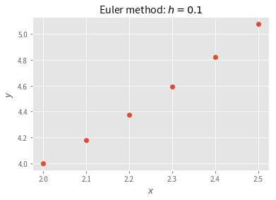

```python
%matplotlib inline
import numpy as np
import matplotlib.pyplot as plt
plt.style.use('ggplot')

x0 = 2.0
y0 = 4.0
xf = 2.5

h = 0.1
n = int((xf -x0)/h) +1

x = np.linspace(x0, xf, n)
y = np.zeros(n)

y[0] = y0
for i in range(1, n):
    y[i] = y[i -1] +h*(0.1 *np.sqrt(y[i -1]) +0.4 *x[i -1]**2)
    print('x = %5.4f, y = %5.4f' % (x[i], y[i]))

plt.plot(x, y,'o')
plt.xlabel("$x$")
plt.ylabel("$y$")
plt.title("Euler method: $h=0.1$")
plt.show()
```

### Exercises 2.6

- 1, 3, 5

## 2.7 Linear Models

**Example:** Series Circuits

- For a series circuit containing a resister $R$ and an inductor $L$, Kirchoff's second law gives

  $\displaystyle L\frac{di}{dt}+Ri=E(t)$

[figure not shown]

- For a series circuit containing a resister and a capacitor, Kirchoff's second law gives

  $\displaystyle Ri+\frac{1}{C}q=E(t)$

  where $\displaystyle i=\frac{dq}{dt}$. Then $\displaystyle R\frac{dq}{dt}+\frac{1}{C}q=E(t)$

[figure not shown]

### Exercises 2.7

- 1, 11, 13, 21, 29, 35

## 2.8 Nonlinear Models

**Example:** Chemical Reactions

$a$ grams of chemical $A$ are reacted with $b$ grams of chemical $B$ to produce $x(t)$ grams of chemical $C$ by consuming $M$ parts of $A$ and $N$ parts of $B$. Applying the law of mass action,

$\displaystyle\frac{dx}{dt} = k \left(a -\frac{M}{M+N}x \right) \left(b-\frac{N}{M+N}x \right)$

### Exercises 2.8

- 2, 5, 10, 11, 13

## 2.9 Modelng with Systems of First-Order DEs

**Example:** Radioactive Series

In radioactive decay series, one substance decays into another and another until a stable element is reached. In the decay of $X \xrightarrow{k_1} Y \xrightarrow{k_2} Z$

- The decay of the initial element $X$ is described by

  $\displaystyle\frac{dx}{dt}=-k_1 x$
- The second element $Y$ is produced by the decay of $X$ and loses from its own spontaneous decay

  $\displaystyle\frac{dy}{dt}=k_1 x -k_2 y$
- The stable element $z$ is generated from the decay $Y$

  $\displaystyle\frac{dz}{dt}=k_2 y$

### Exercises 2.9

- 1, 6, 10